# Regression Analysis on AAPL Stock Prices

Archit H, Yashsmmita L, Sneha P, Soham S

2025-02-16

# Introduction

This report aims to analyze the relationship between the closing stock price of Apple Inc. (AAPL) and other key market indicators such as open price, high price, low price, and trading volume. The objective is to develop a linear regression model to predict the closing price based on these variables.

# Dataset Description

The dataset contains daily stock price information for AAPL with the following variables:

- **Date:** Trading date
- **Low:** Lowest price of the stock on that day
- **Open:** Opening price
- **Volume:** Number of shares traded
- **High:** Highest price
- **Close:** Closing price
- **Adjusted Close:** Adjusted closing price after dividends and stock splits

# Methodology

## Load Libraries

```r
library(ggplot2)
library(car)
library(Metrics)
library(corrplot)
```

## Read Dataset

```r
aapl_data <- read.csv("AAPL.csv", stringsAsFactors = FALSE)
aapl_data$Date <- as.Date(aapl_data$Date, format = "%Y-%m-%d")
```

## Summary Statistics

```r
summary(aapl_data)
```

```
##       Date                 Low                 Open
##  Min.   :0001-02-19   Min.   :  0.04911   Min.   :  0.04967
##  1st Qu.:0008-09-20   1st Qu.:  0.28013   1st Qu.:  0.28666
##  Median :0016-03-19   Median :  0.47750   Median :  0.48438
##  Mean   :0016-03-31   Mean   : 16.14108   Mean   : 16.32397
##  3rd Qu.:0023-09-20   3rd Qu.: 15.80054   3rd Qu.: 16.00929
##  Max.   :0031-12-20   Max.   :179.12000   Max.   :182.63000
##      Volume               High               Close
##  Min.   :0.000e+00   Min.   :  0.04967   Min.   :  0.04911
##  1st Qu.:1.216e+08   1st Qu.:  0.29370   1st Qu.:  0.28683
##  Median :2.151e+08   Median :  0.49330   Median :  0.48438
##  Mean   :3.280e+08   Mean   : 16.50955   Mean   : 16.33214
##  3rd Qu.:4.070e+08   3rd Qu.: 16.17920   3rd Qu.: 15.96875
##  Max.   :7.422e+09   Max.   :182.94000   Max.   :182.00999
##  Adjusted.Close
##  Min.   :  0.03821
##  1st Qu.:  0.23723
##  Median :  0.40178
##  Mean   : 15.66094
##  3rd Qu.: 13.83144
##  Max.   :180.95975
```

```r
colSums(is.na(aapl_data))
```

```
##           Date            Low           Open         Volume           High
##              0              0              0              0              0
##          Close Adjusted.Close
##              0              0
```

## Exploratory Data Analysis

### Scatterplot Matrix

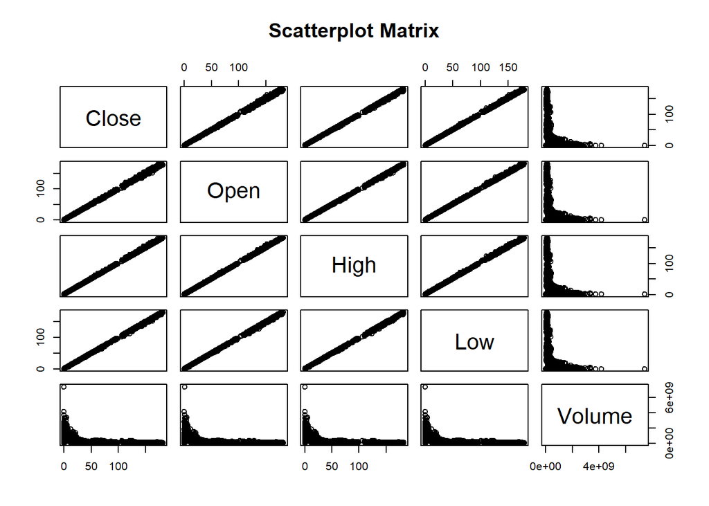

```r
pairs(~Close + Open + High + Low + Volume, data = aapl_data, main = "Scatterplot Matrix")
```

### Correlation Matrix

```r
correlation_matrix <- cor(aapl_data[, c("Close", "Open", "High", "Low", "Volume")])
print(correlation_matrix)
```

```
##             Close       Open       High        Low     Volume
## Close   1.0000000  0.9998400  0.9999245  0.9999258 -0.2109494
## Open    0.9998400  1.0000000  0.9999389  0.9999241 -0.2107747
## High    0.9999245  0.9999389  1.0000000  0.9999101 -0.2102412
## Low     0.9999258  0.9999241  0.9999101  1.0000000 -0.2116362
## Volume -0.2109494 -0.2107747 -0.2102412 -0.2116362  1.0000000
```

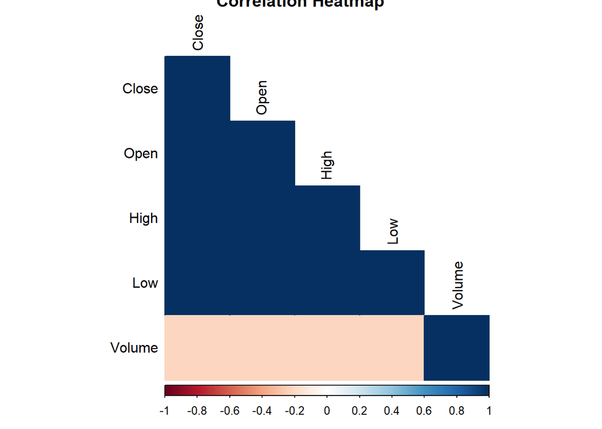

```r
corrplot(correlation_matrix, method = "color", type = "lower", tl.col = "black",
 main = "Correlation Heatmap")
```

### Distribution of Close Prices

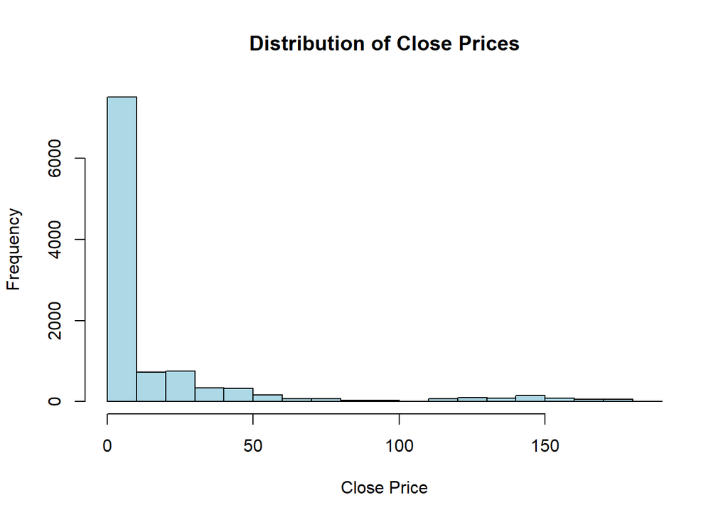

```r
hist(aapl_data$Close, main = "Distribution of Close Prices",
xlab = "Close Price", col = "lightblue")
```

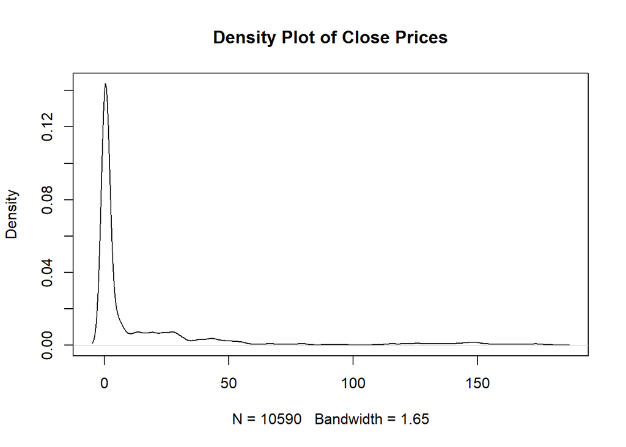

```r
plot(density(aapl_data$Close), main = "Density Plot of Close Prices")
```

## Linear Regression Model

```r
model <- lm(Close ~ Open + High + Low + Volume, data = aapl_data)
summary(model)
```

```
##
## Call:
## lm(formula = Close ~ Open + High + Low + Volume, data = aapl_data)
##
## Residuals:
##     Min      1Q  Median      3Q     Max
## -4.4619 -0.0062 -0.0016  0.0030  5.1238
##
## Coefficients:
##               Estimate Std. Error t value Pr(>|t|)
## (Intercept)  1.042e-03  4.216e-03   0.247    0.805
## Open        -6.767e-01  8.109e-03 -83.446   <2e-16 ***
## High         8.762e-01  7.385e-03 118.648   <2e-16 ***
## Low          7.998e-01  6.800e-03 117.625   <2e-16 ***
## Volume       2.525e-12  8.215e-12   0.307    0.759
## ---
## Signif. codes:  0 '***' 0.001 '**' 0.01 '*' 0.05 '.' 0.1 ' ' 1
##
## Residual standard error: 0.2777 on 10585 degrees of freedom
## Multiple R-squared:  0.9999, Adjusted R-squared:  0.9999
## F-statistic: 4.189e+07 on 4 and 10585 DF,  p-value: < 2.2e-16
```

## Check for Multicollinearity

```r
vif(model)
```

```
##         Open         High          Low       Volume
## 11003.519578  9348.511334  7557.052855     1.058591
```

## Model Diagnostics

### Actual vs Predicted Plot

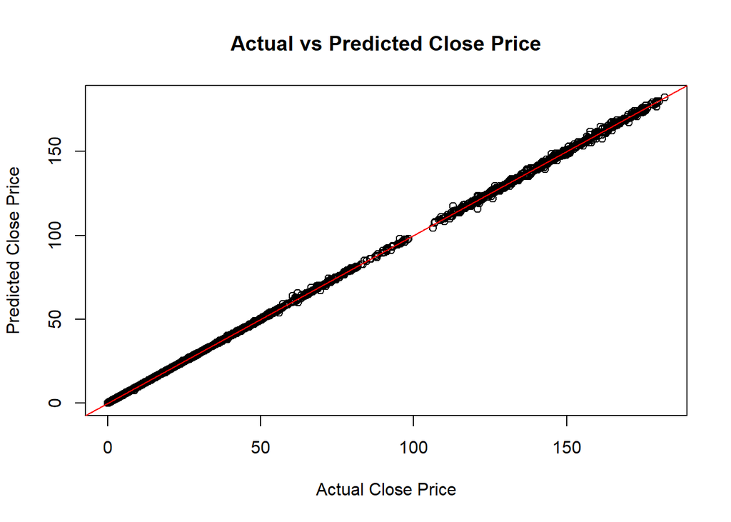

```r
plot(aapl_data$Close, predict(model), main = "Actual vs Predicted Close Price",
 xlab = "Actual Close Price", ylab = "Predicted Close Price")
abline(0, 1, col = "red")
```

### Residual Plot

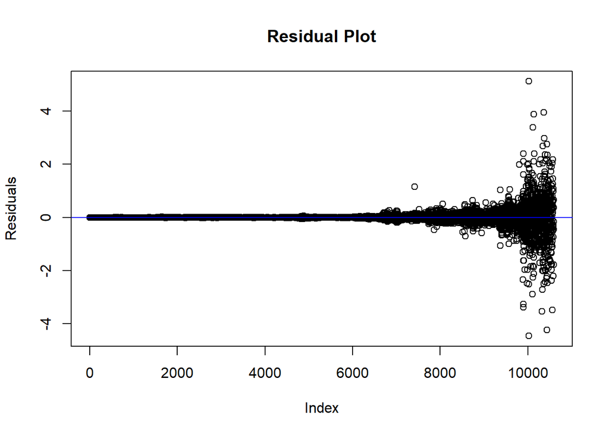

```r
plot(model$residuals, main = "Residual Plot", ylab = "Residuals", xlab = "Index")
abline(h = 0, col = "blue")
```